# Survey Results

## Data

```r
library(tidyverse)
d <- read_csv("SurveyData/survey_responses_ENG_TRANS.csv")
```

# National Opinion Distributions

### NSEC

Denmark currently faces serious security threats.

Denmark spends too much money on supporting Ukraine in the war against Russia.

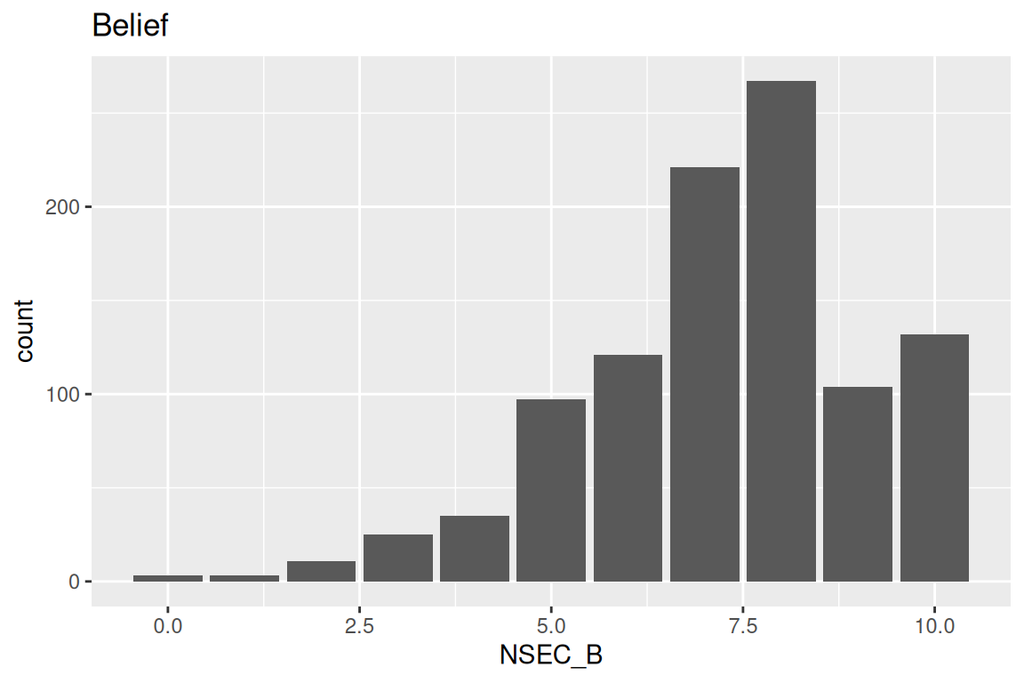

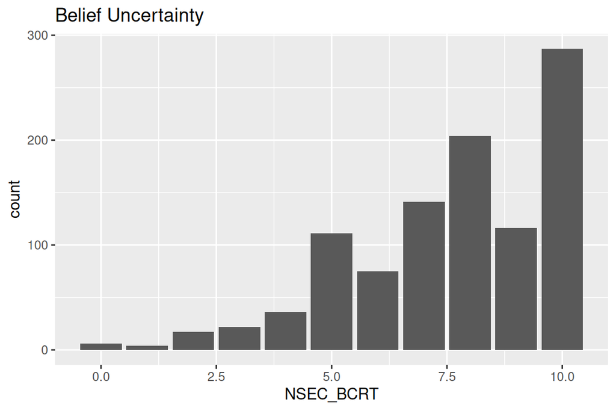

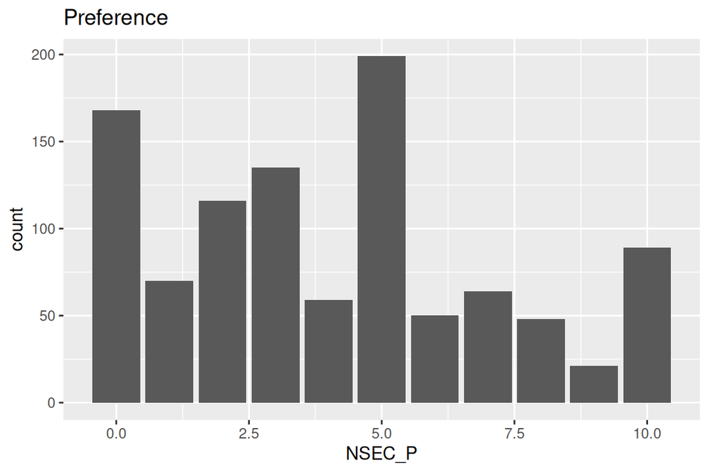

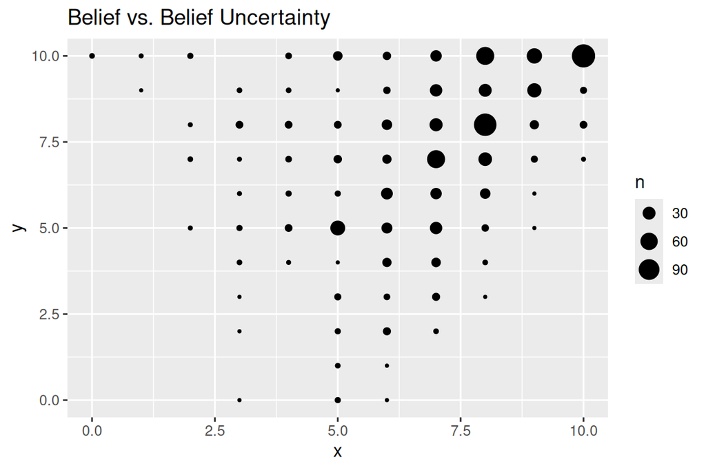

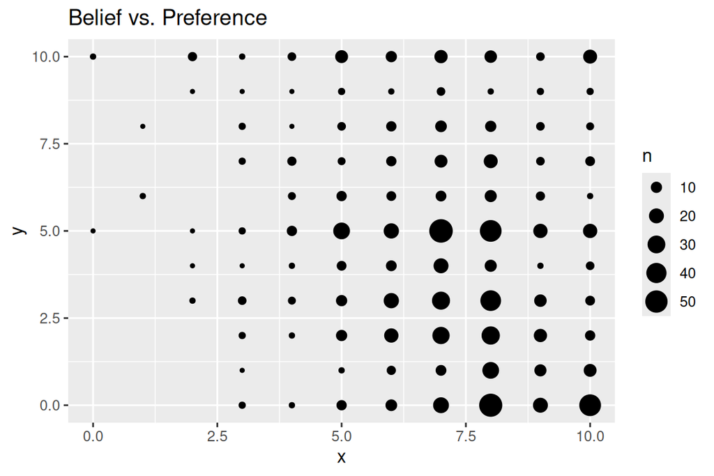

### NECN

Economic inequality in Denmark is too high.

The tax for the highest incomes must be raised

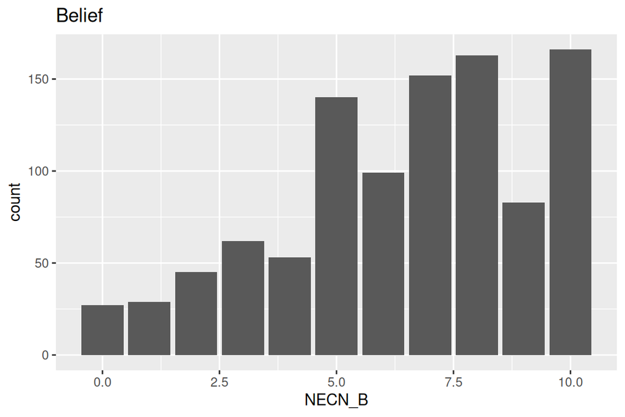

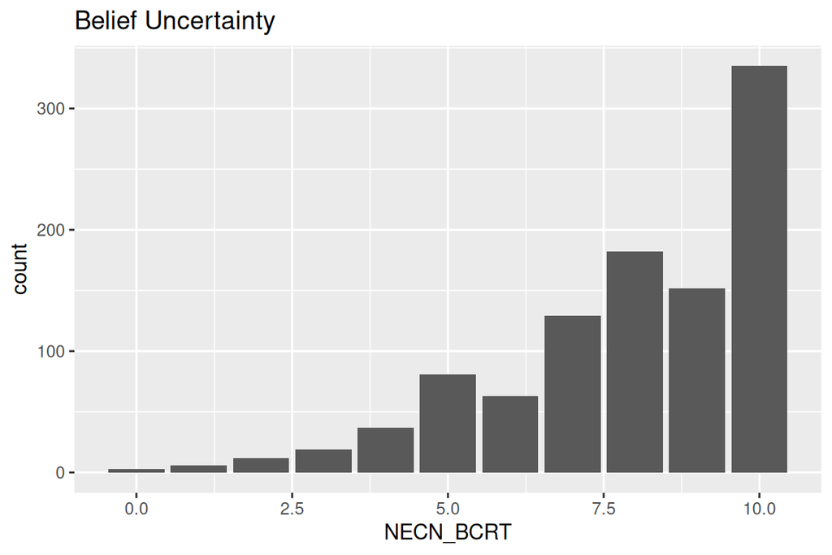

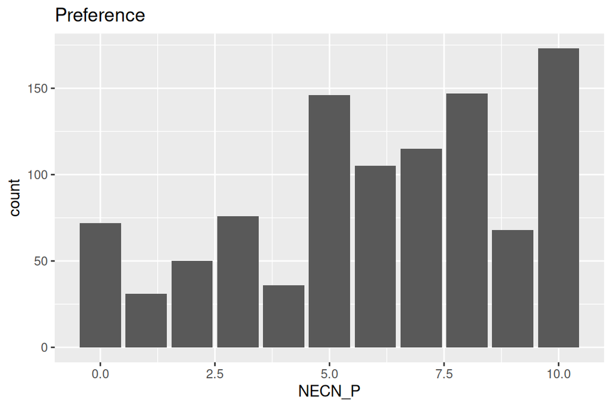

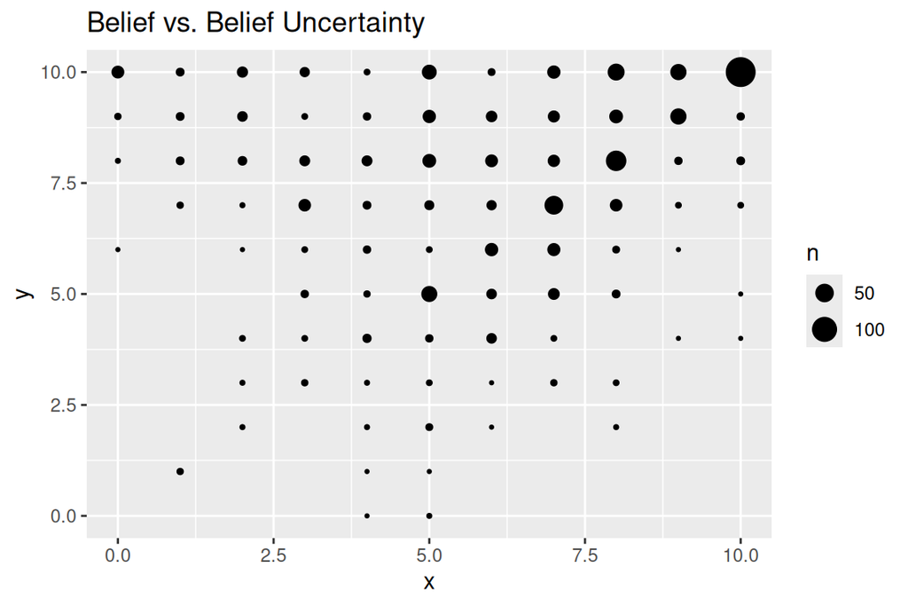

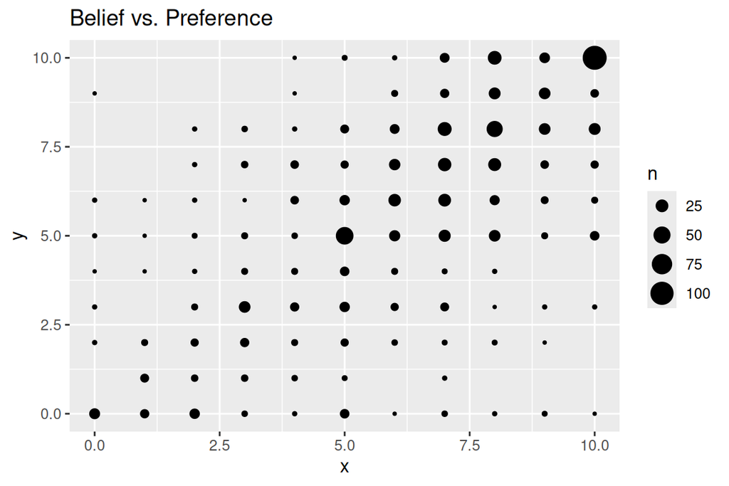

### NWLF

People in Denmark who need public support do not always receive enough help.

The transfer income for the poorest cash assistance recipients must be increased.

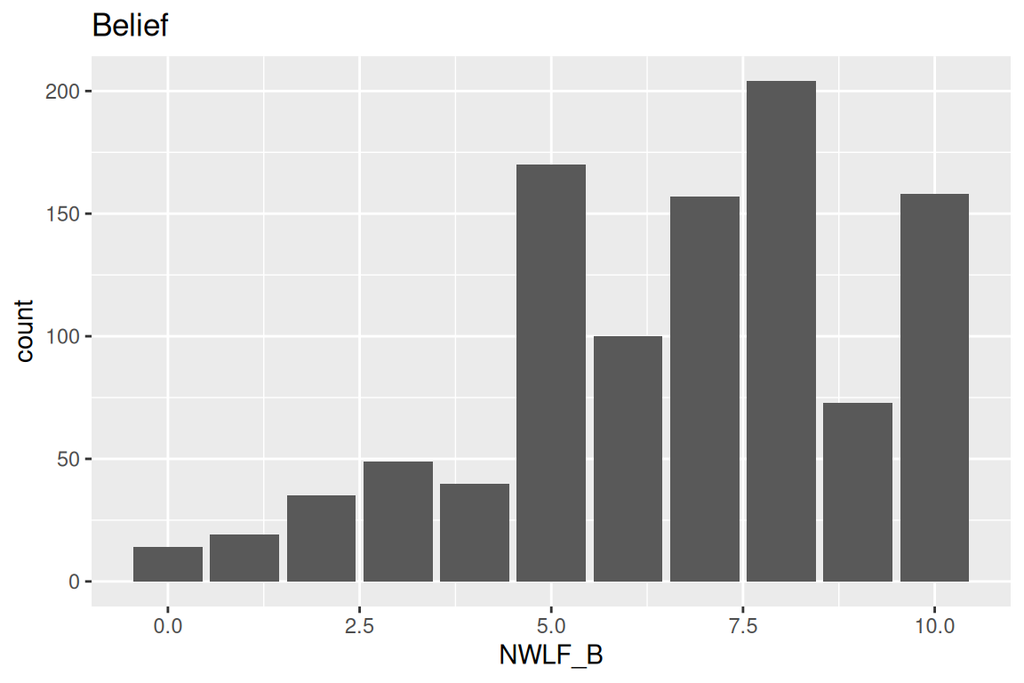

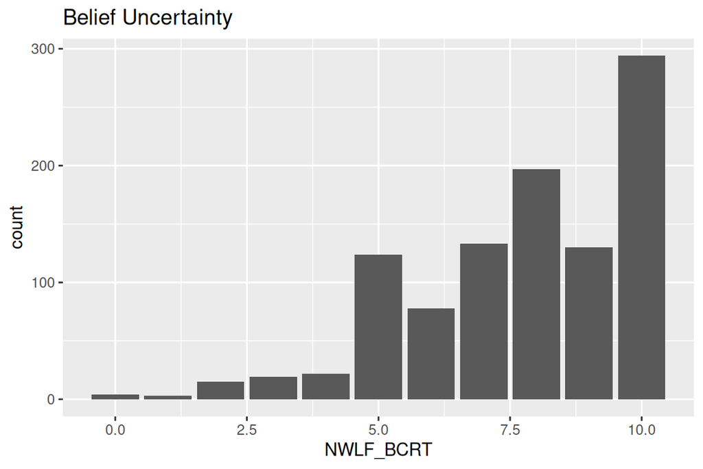

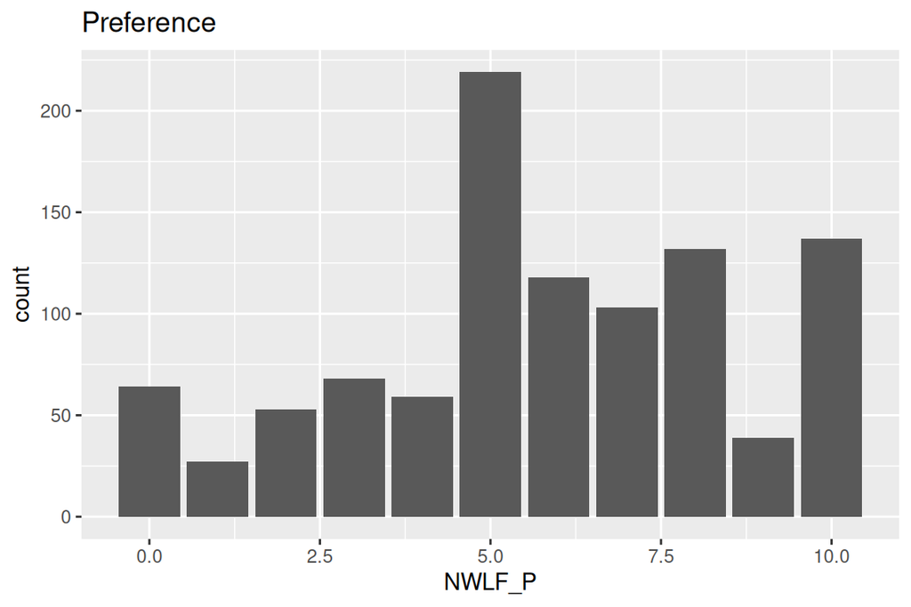

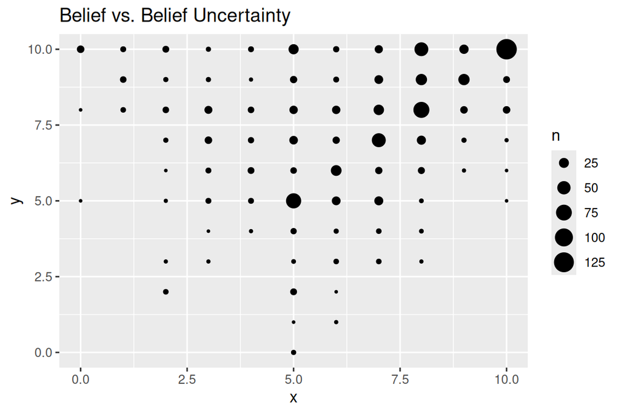

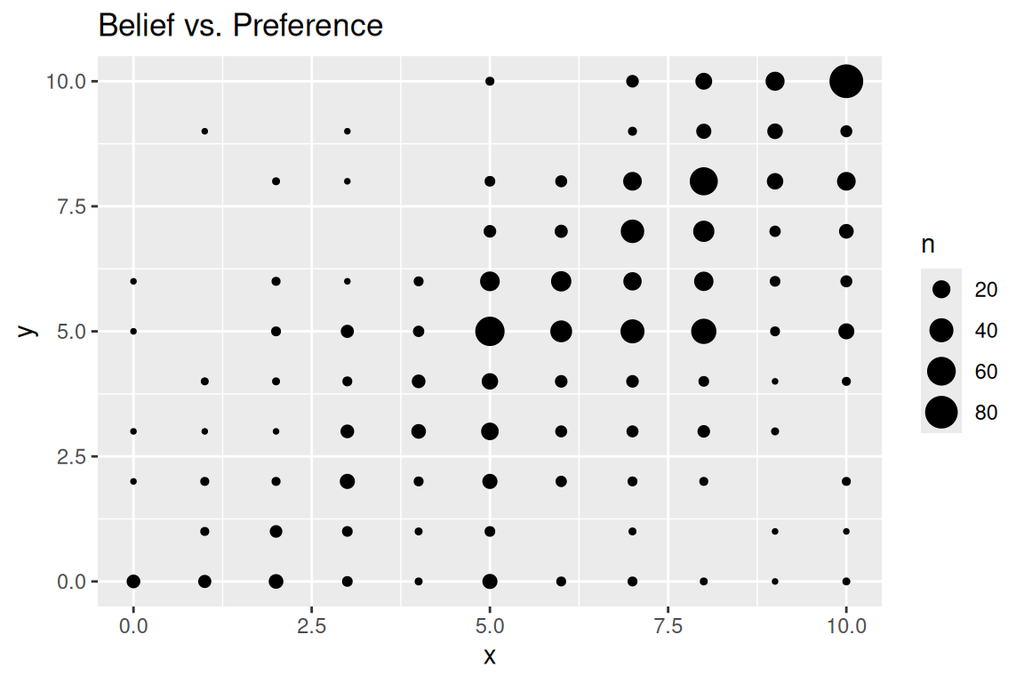

### NIMG

Immigrants in Denmark are not integrating well into society.

More foreign labor from countries outside Europe and North America must be opened up.

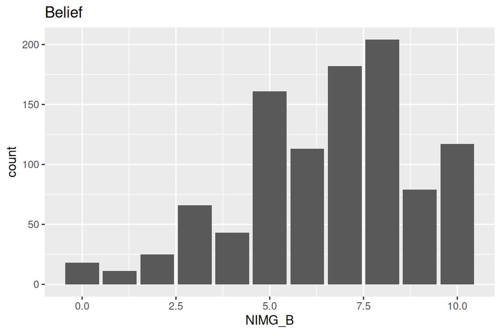

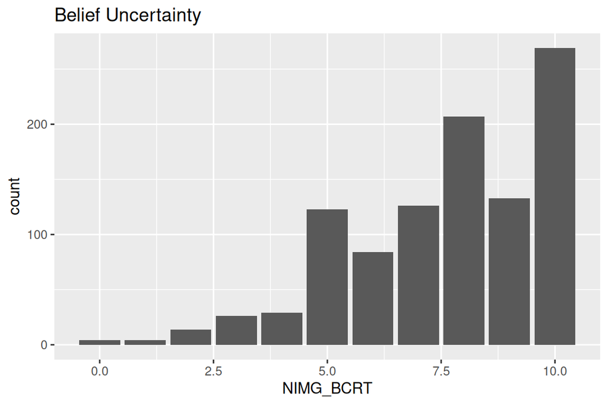

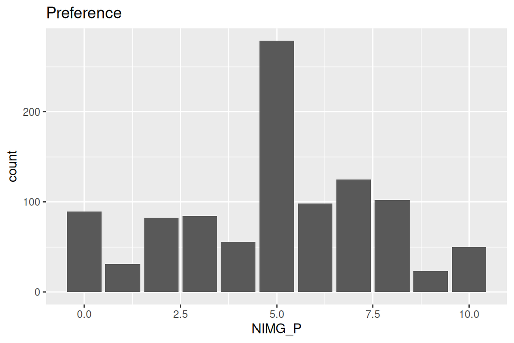

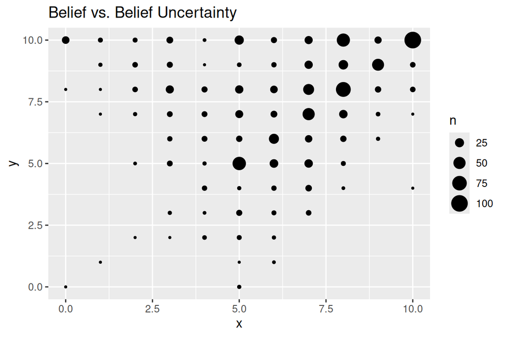

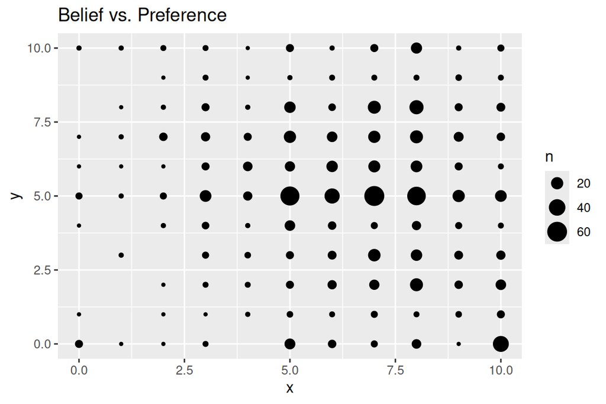

### NCLM

Climate change poses an urgent threat to Denmark.

Nuclear power on Danish soil must be part of the energy supply in the long term.

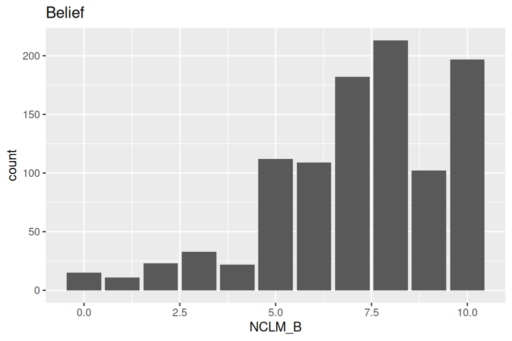

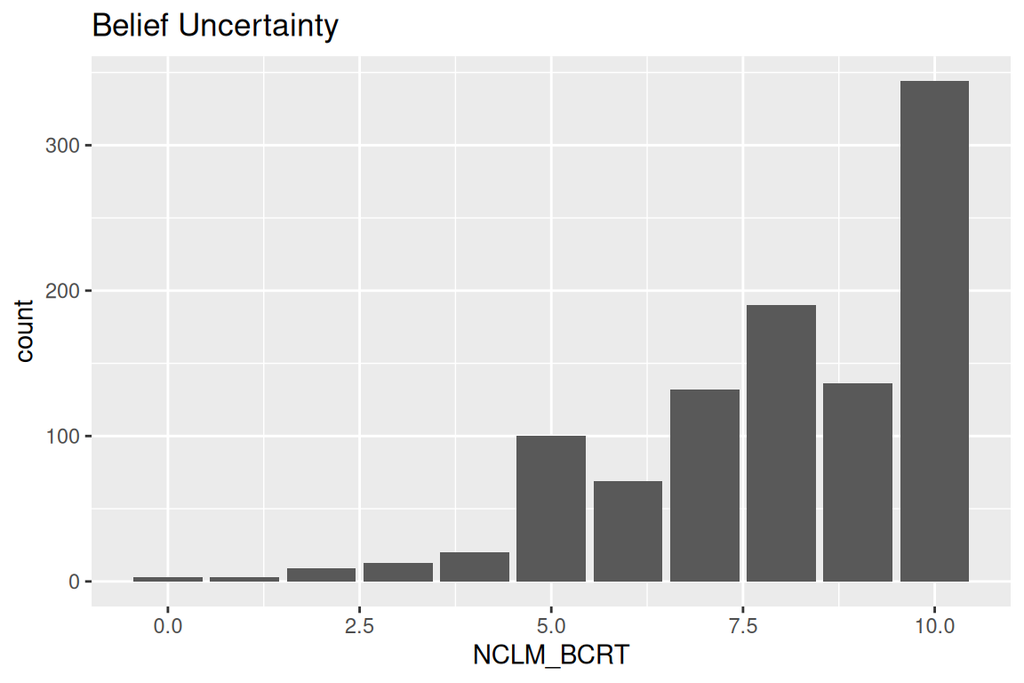

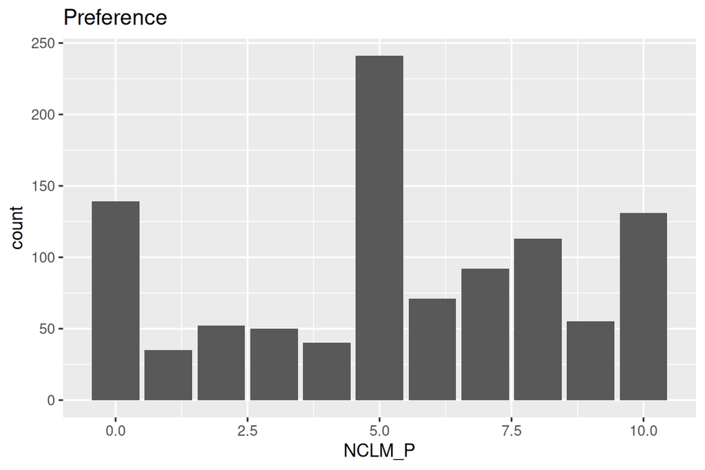

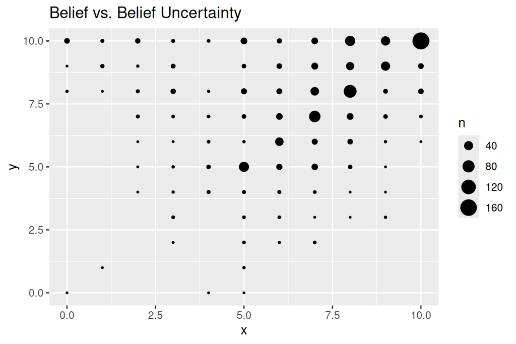

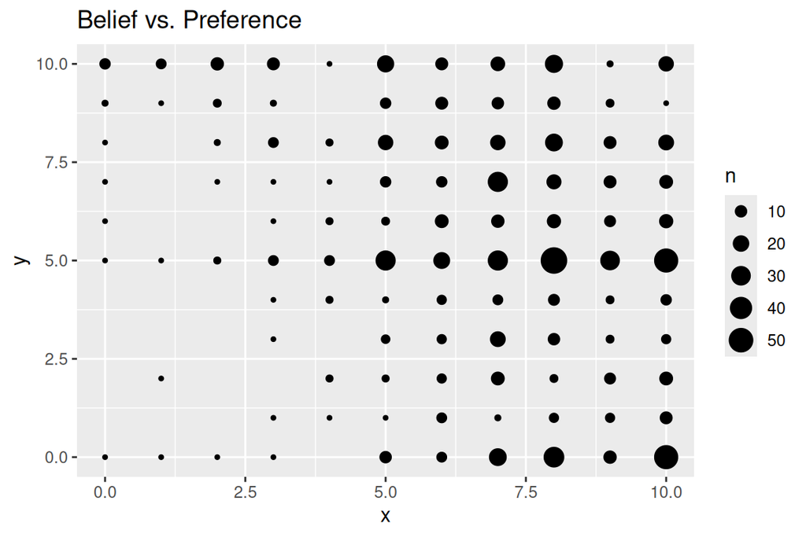

In Danish national elections, each voter casts one vote for a party or candidate; and seats in Parliament are allocated using proportional representation. Overall, how satisfied are you with this voting system?

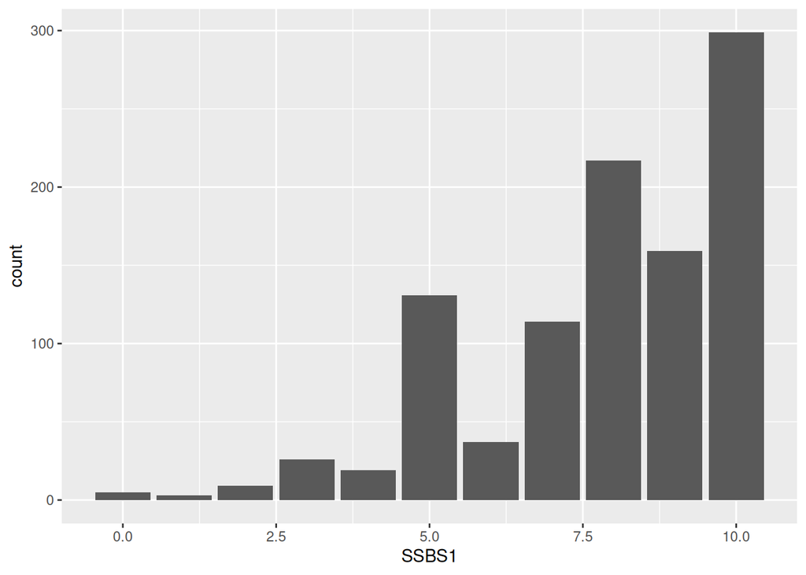

```r
d |> ggplot(aes(x = SSBS1)) + geom_bar()
```

I am confident that I understand how my vote is translated into the final election outcome under the current system.

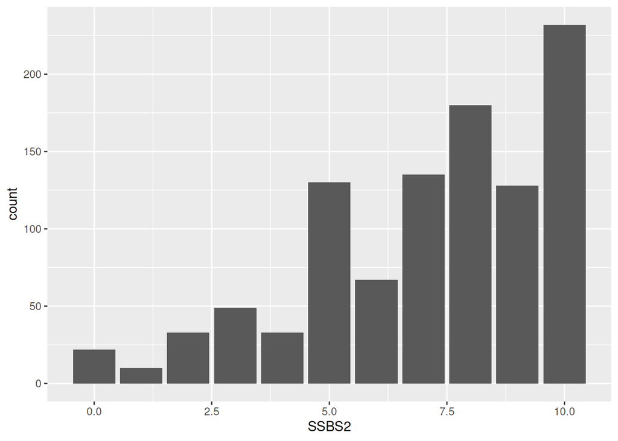

```r
d |> ggplot(aes(x = SSBS2)) + geom_bar()
```

In some electoral systems, voters can allocate more than one vote across candidates or parties, rather than casting only a single vote. To what extent would you support or oppose introducing such a system?

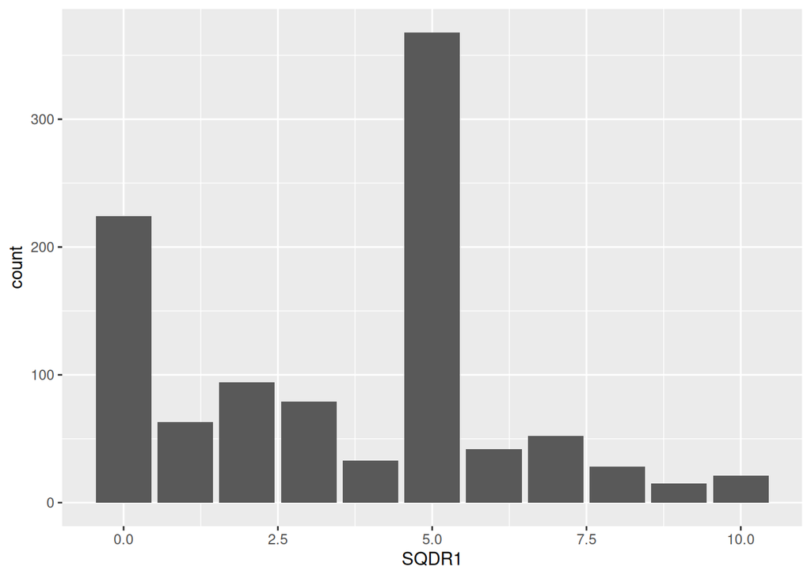

```r
d |> ggplot(aes(x = SQDR1)) + geom_bar()
```

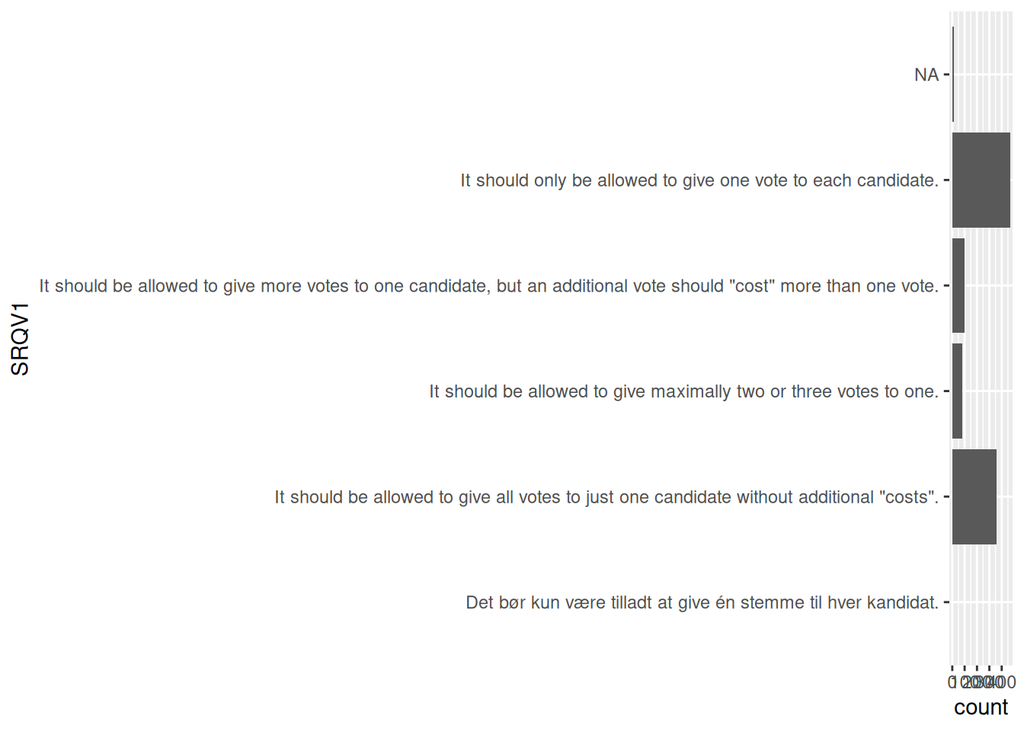

```r
d |> ggplot(aes(y = SRQV1)) + geom_bar()
```